# Session 10: Data Science Capstone Project

K. Roopa Yashaswini

2024-12-23

# 1 Introduction and learning objectives

The purpose of this exercise is to build an estimation engine to guide investment decisions in London house market. You will first build machine learning algorithms (and tune them) to estimate the house prices given variety of information about each property. Then, using your algorithm, you will choose 200 houses to invest in out of about 2000 houses on the market at the moment.

**Learning objectives**

1. Using different data mining algorithms for prediction.
2. Dealing with large data sets
3. Tuning data mining algorithms
4. Interpreting data mining algorithms and deducing importance of variables
5. Using results of data mining algorithms to make business decisions

# 2 Load data

There are two sets of data, i) training data that has the actual prices ii) out of sample data that has the asking prices. Load both data sets.

Make sure you understand what information each column contains. Note that not all information provided might be useful in predicting house prices, but do not make any assumptions before you decide what information you use in your prediction algorithms.

```r
#read in the data

london_house_prices_2019_training <- read.csv("training_data_assignment_with_prices.csv")
london_house_prices_2019_out_of_sample <- read.csv("test_data_assignment.csv")



#fix data types in both data sets

#fix dates
london_house_prices_2019_training <- london_house_prices_2019_training %>%
  mutate(
    date=as.Date(date)
    )
london_house_prices_2019_out_of_sample <- london_house_prices_2019_out_of_sample %>%
  mutate(
    date=as.Date(date)
    )
#change characters to factors
london_house_prices_2019_training <- london_house_prices_2019_training %>%
  mutate_if(is.character,as.factor)
london_house_prices_2019_out_of_sample<-london_house_prices_2019_out_of_sample %>%
  mutate_if(is.character,as.factor)

#take a quick look at what's in the data
str(london_house_prices_2019_training)
```

```
## 'data.frame':    13998 obs. of  37 variables:
##  $ ID                          : int  2 3 4 5 7 8 9 10 11 12 ...
##  $ date                        : Date, format: "2019-11-01" "2019-08-08" ...
##  $ postcode                    : Factor w/ 12635 levels "BR1 1AB","BR1 1LR",..: 10897 11027 11264 2031 11241 11066 421 9594 9444 873 ...
##  $ property_type               : Factor w/ 4 levels "D","F","S","T": 2 2 3 2 3 2 1 4 4 2 ...
##  $ whether_old_or_new          : Factor w/ 2 levels "N","Y": 1 1 1 1 1 1 1 1 1 1 ...
##  $ freehold_or_leasehold       : Factor w/ 2 levels "F","L": 2 2 1 2 1 2 1 1 1 2 ...
##  $ address1                    : Factor w/ 2825 levels "1","1 - 2","1 - 3",..: 2503 792 253 789 569 234 264 418 5 274 ...
##  $ address2                    : Factor w/ 434 levels "1","10","101",..: 372 NA NA NA NA NA NA NA NA NA ...
##  $ address3                    : Factor w/ 8543 levels "ABBERTON WALK",..: 6990 6821 3715 2492 4168 2879 3620 5251 6045 6892 ...
##  $ town                        : Factor w/ 133 levels "ABBEY WOOD","ACTON",..: NA NA NA 78 NA NA NA NA NA NA ...
##  $ local_aut                   : Factor w/ 69 levels "ASHFORD","BARKING",..: 36 46 24 36 24 46 65 36 36 17 ...
##  $ county                      : Factor w/ 33 levels "BARKING AND DAGENHAM",..: 22 27 18 25 18 27 5 27 32 8 ...
##  $ postcode_short              : Factor w/ 247 levels "BR1","BR2","BR3",..: 190 194 198 28 198 194 4 169 167 8 ...
##  $ current_energy_rating       : Factor w/ 6 levels "B","C","D","E",..: 4 3 3 4 3 2 4 3 4 2 ...
```

[output cut: 23 more lines]

```r
str(london_house_prices_2019_out_of_sample)
```

```
## 'data.frame':    1999 obs. of  37 variables:
##  $ ID                          : int  14434 12562 8866 10721 1057 1527 13961 12108 9363 1155 ...
##  $ date                        : Date, format: NA NA ...
##  $ postcode                    : logi  NA NA NA NA NA NA ...
##  $ property_type               : Factor w/ 4 levels "D","F","S","T": 1 2 2 3 4 3 2 3 2 4 ...
##  $ whether_old_or_new          : Factor w/ 2 levels "N","Y": 1 1 1 1 1 1 1 1 1 1 ...
##  $ freehold_or_leasehold       : Factor w/ 2 levels "F","L": 1 2 2 1 1 1 2 1 2 1 ...
##  $ address1                    : logi  NA NA NA NA NA NA ...
##  $ address2                    : logi  NA NA NA NA NA NA ...
##  $ address3                    : logi  NA NA NA NA NA NA ...
##  $ town                        : Factor w/ 54 levels "ACTON","ADDISCOMBE",..: NA NA NA NA NA NA NA NA NA NA ...
##  $ local_aut                   : logi  NA NA NA NA NA NA ...
##  $ county                      : logi  NA NA NA NA NA NA ...
##  $ postcode_short              : Factor w/ 221 levels "BR1","BR2","BR3",..: 82 50 37 52 214 150 159 115 175 126 ...
##  $ current_energy_rating       : Factor w/ 6 levels "B","C","D","E",..: 3 2 3 3 4 4 4 3 4 3 ...
```

[output cut: 23 more lines]

```r
#let's do the initial split
library(rsample)
train_test_split <- initial_split(london_house_prices_2019_training, prop = 0.75) #training set contains 75% of the data
# Create the training dataset
train_data <- training(train_test_split)
test_data <- testing(train_test_split)
```

# 3 Visualize data

Visualize and examine the data. What plots could be useful here? What do you learn from these visualizations?

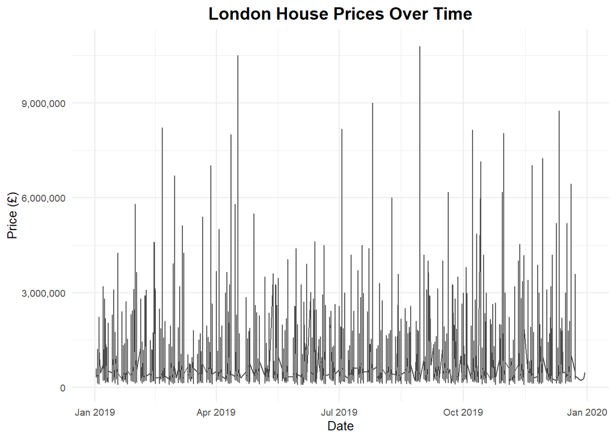

```r
ggplot(london_house_prices_2019_training, aes(x = date, y = price)) +
  # Define the aesthetics: 'date' is mapped to x-axis and 'price' to y-axis
  geom_line(size = 0.5, alpha = 0.7) +
  # Add a line plot with a line thickness of 0.5 and transparency of 0.7

  labs(
    title = "London House Prices Over Time",  # Add a title to the plot
    x = "Date",                              # Label for the x-axis
    y = "Price (£)"                          # Label for the y-axis
  ) +

  theme_minimal() +
  # Apply a minimal theme for a clean and simple appearance

  scale_y_continuous(labels = scales::comma) +
  # Format the y-axis labels to include commas for thousands (e.g., 1,000)

  theme(
    plot.title = element_text(hjust = 0.5, size = 14, face = "bold"),
    # Center-align the title (hjust = 0.5), set the font size to 14, and make it bold

    axis.title = element_text(size = 10),
    # Set the font size of axis titles to 10

    axis.text = element_text(size = 8)
    # Set the font size of axis text (tick labels) to 8
  )
```

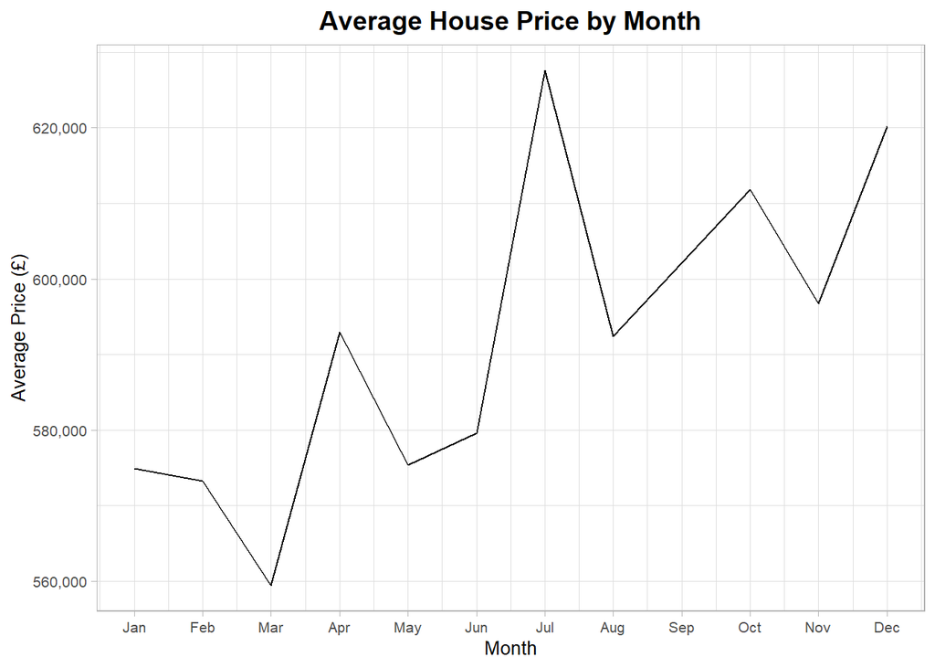

```r
london_house_prices_2019_training %>%
  mutate(month = month(date)) %>%  # Extract the month from the 'date' column and create a new 'month' column

  group_by(month) %>%  # Group the data by the 'month' column to calculate monthly averages

  summarise(avg_price = mean(price)) %>%  # Calculate the average house price for each month

  ggplot(aes(x = month, y = avg_price)) +  # Create a plot with 'month' on the x-axis and 'avg_price' on the y-axis

  geom_line(size = 0.5) +  # Add a line plot with a thickness of 0.5 for better visibility

  scale_x_continuous(breaks = 1:12, labels = month.abb) +  # Set the x-axis breaks from 1 to 12 (for each month) and display month abbreviations (Jan, Feb, etc.)

  scale_y_continuous(labels = scales::comma) +  # Format the y-axis labels with commas for easier reading (e.g., 1,000 instead of 1000)

  labs(  # Add labels for the x-axis, y-axis, and the plot title
    x = "Month",  # Label for the x-axis
    y = "Average Price (£)",  # Label for the y-axis
    title = "Average House Price by Month"  # Title of the plot
  ) +

  theme_light() +  # Use a light theme for the plot background and gridlines

  theme(  # Customize the appearance of plot elements
    plot.title = element_text(hjust = 0.5, size = 14, face = "bold"),  # Center the plot title, set font size to 14, and make it bold
    axis.title = element_text(size = 10),  # Set font size for axis titles to 10
    axis.text = element_text(size = 8)  # Set font size for axis tick labels to 8
  )
```

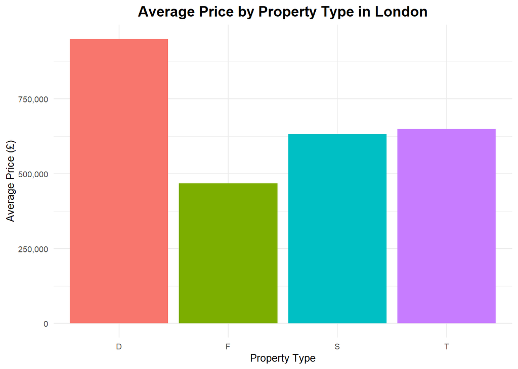

```r
london_house_prices_2019_training %>%

  group_by(property_type) %>%  # Group the data by 'property_type' to calculate the average price for each type

  summarise(avg_price = mean(price)) %>%  # Calculate the average price for each property type

  ggplot(aes(x = property_type, y = avg_price, fill = property_type)) +  # Create a bar plot with 'property_type' on the x-axis and 'avg_price' on the y-axis. Color bars by 'property_type'

    geom_col(show.legend = FALSE) +  # Use bars for visualization (geom_col), hide the legend as it is not necessary

    scale_y_continuous(labels = scales::comma) +  # Format the y-axis labels with commas for better readability (e.g., 1,000 instead of 1000)

    labs(  # Add labels for the axes and title of the plot
      x = "Property Type",  # Label for the x-axis
      y = "Average Price (£)",  # Label for the y-axis
      title = "Average Price by Property Type in London"  # Title of the plot
    ) +

    theme_minimal() +  # Use a minimal theme for a clean and simple background

    theme(  # Customize plot text appearance
      plot.title = element_text(hjust = 0.5, size = 14, face = "bold"),  # Center the plot title, set font size to 14, and make it bold
      axis.title = element_text(size = 10),  # Set font size for axis titles to 10
      axis.text = element_text(size = 8)  # Set font size for axis tick labels to 8
    )
```

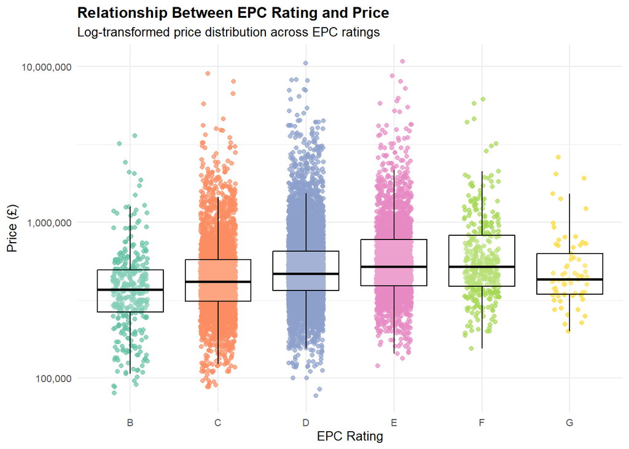

```r
ggplot(london_house_prices_2019_training, aes(x = current_energy_rating, y = price, color = current_energy_rating)) +  # Create a scatter plot with 'current_energy_rating' on the x-axis, 'price' on the y-axis, and color the points by 'current_energy_rating'

  geom_jitter(width = 0.2, alpha = 0.7) +  # Add jitter to the points (to prevent overlap), with a width of 0.2 and alpha transparency set to 0.7 for better visualization

  geom_boxplot(aes(group = current_energy_rating), alpha = 0.2, color = "black", outlier.shape = NA) +  # Overlay a boxplot for each EPC rating (grouped by 'current_energy_rating'), with alpha transparency for the box and no outlier markers

  scale_color_brewer(palette = "Set2") +  # Apply a color palette from ColorBrewer ("Set2") for better visual distinction between EPC ratings

  scale_y_log10(labels = scales::comma) +  # Apply a log10 scale to the y-axis to better handle large price values, with formatted labels that include commas for readability

  labs(  # Add labels for the plot
    title = "Relationship Between EPC Rating and Price",  # Title of the plot
    subtitle = "Log-transformed price distribution across EPC ratings",  # Subtitle explaining the plot context
    x = "EPC Rating",  # Label for the x-axis
    y = "Price (£)",  # Label for the y-axis
    color = "EPC Rating"  # Label for the color legend
  ) +
  theme_minimal(base_size = 10) +  # Use a minimal theme with a larger base font size (10) for readability

  theme(  # Customize plot text and other elements
    plot.title = element_text(face = "bold"),  # Make the plot title bold
    legend.position = "none"  # Remove the legend from the plot as it is not needed (since color is already encoded in the points)
  )
```

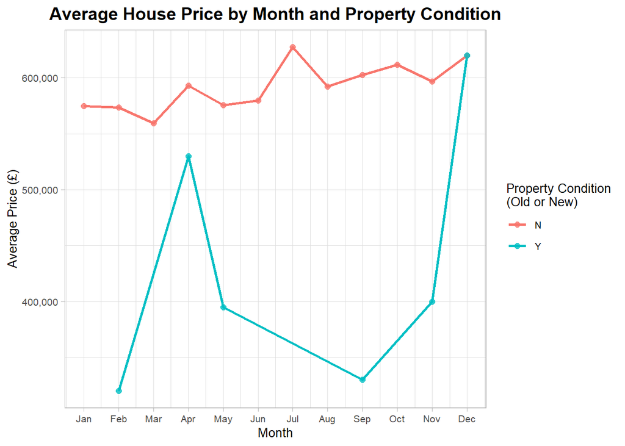

```r
# Create the line chart
london_house_prices_2019_training %>%
  mutate(month = month(date)) %>%  # Extract month from date
  group_by(month, whether_old_or_new) %>%  # Group by month
  summarise(avg_price = mean(price)) %>%
  ggplot(aes(x = month, y = avg_price, color = whether_old_or_new)) +
  geom_line(size = 1) +  # Thicker lines for better visibility
  geom_point(size = 2, alpha = 0.8) +  # Add points with some transparency
  scale_x_continuous(breaks = 1:12, labels = month.abb) +  # Month abbreviations
  scale_y_continuous(labels = scales::comma) +  # Format y-axis labels
  labs(
    x = "Month",
    y = "Average Price (£)",
    title = "Average House Price by Month and Property Condition",
    color = "Property Condition\n(Old or New)"
  ) +
  theme_light() +
  theme(
    plot.title = element_text(hjust = 0.5, size = 14, face = "bold"),
    axis.title = element_text(size = 10),
    axis.text = element_text(size = 8),
    legend.title = element_text(size = 10),
    legend.text = element_text(size = 8)
  )
```

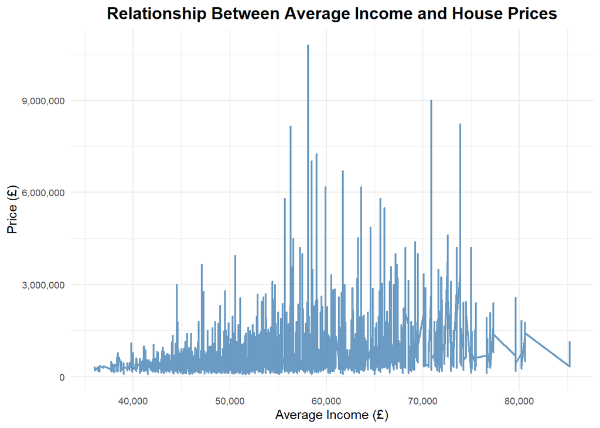

```r
ggplot(london_house_prices_2019_training, aes(x = average_income, y = price)) +  # Create a line plot with 'average_income' on the x-axis and 'price' on the y-axis

  geom_line(color = "steelblue", size = 0.8, alpha = 0.8) +  # Add a line to the plot with 'steelblue' color, line size of 0.8, and alpha transparency of 0.8 for a slightly faded appearance

  labs(  # Add titles and axis labels to the plot
    title = "Relationship Between Average Income and House Prices",  # Main title of the plot
    x = "Average Income (£)",  # Label for the x-axis
    y = "Price (£)"  # Label for the y-axis
  ) +

  scale_y_continuous(labels = scales::comma) +  # Format y-axis labels with commas for easier readability (e.g., 1,000 instead of 1000)

  scale_x_continuous(labels = scales::comma) +  # Format x-axis labels with commas for easier readability (e.g., 1,000 instead of 1000)

  theme_minimal() +  # Use a minimalistic theme for a clean plot appearance

  theme(  # Customize plot text and other elements
    plot.title = element_text(face = "bold", size = 14, hjust = 0.5),  # Make the plot title bold, set font size to 14, and center-align the title

    axis.text = element_text(size = 8)  # Increase the font size of the axis tick labels to 8 for better readability
  )
```

[figure not shown]

```r
london_house_prices_2019_training %>%
  group_by(district) %>%  # Group the data by 'district' to calculate average price per district

  summarise(avg_price_by_district = mean(price)) %>%  # Calculate the average house price for each district

  mutate(district = fct_reorder(district, avg_price_by_district)) %>%  # Reorder the districts by average price in ascending order

  slice_head(n = 20) %>%  # Select the top 20 districts with the highest average price

  ggplot(aes(x = avg_price_by_district, y = district, fill = avg_price_by_district)) +  # Create a horizontal bar plot with 'avg_price_by_district' on the x-axis and 'district' on the y-axis, fill color based on average price

  geom_col(show.legend = FALSE) +  # Plot the bars using 'geom_col' and remove the legend (since it's not necessary for the plot)

  scale_fill_gradient(low = "skyblue", high = "blue") +  # Apply a color gradient fill, where low values are 'skyblue' and high values are 'blue'

  labs(  # Add titles and axis labels
    title = "Top 20 Districts by Average House Price",  # Title of the plot
    x = "Average Price (£)",  # Label for the x-axis
    y = "District"  # Label for the y-axis
  ) +

  scale_x_continuous(labels = scales::comma) +  # Format the x-axis with commas to separate thousands for better readability

  theme_minimal() +  # Use a minimal theme with a clean and simple design

  theme(  # Customize plot elements for better presentation
    plot.title = element_text(face = "bold", size = 16, hjust = 0.5),  # Make the plot title bold, set font size to 16, and center-align it
    axis.title = element_text(face = "bold"),  # Make axis titles bold for emphasis
    axis.text = element_text(size = 8)  # Increase the font size of axis tick labels for readability
  )
```

Estimate a correlation table between prices and other continuous variables. What do you glean from the correlation table?

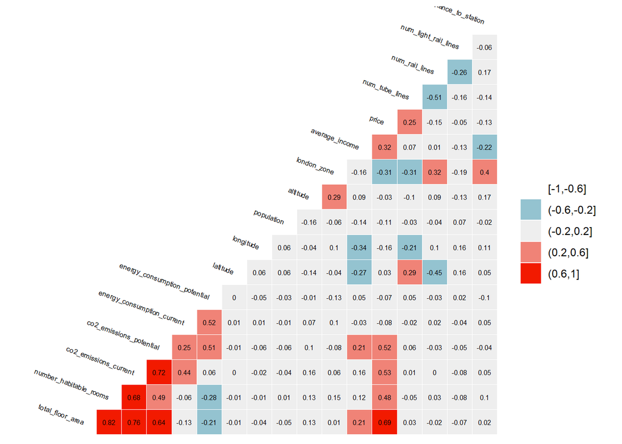

```r
library("GGally")  # Load the GGally package, which extends ggplot2 with additional functions like ggcorr

london_house_prices_2019_training %>%
  select(-ID) %>%  # Remove the 'ID' column from the dataset as it is not needed for the correlation plot

  ggcorr(  # Create a correlation matrix plot using the ggcorr function
    method = c("pairwise", "pearson"),  # Use the Pearson correlation coefficient for pairwise comparisons of variables

    layout.exp = 2,  # Adjust the layout of the plot (higher values spread the plot more)

    label_round = 2,  # Round the correlation coefficient values to 2 decimal places for readability

    label = TRUE,  # Display correlation coefficient values as labels on the plot

    label_size = 2,  # Set the size of the correlation coefficient labels

    hjust = 1,  # Adjust the horizontal justification of the labels to the right

    nbreaks = 5,  # Set the number of breaks (intervals) for the color scale

    size = 2,  # Set the size of the circles representing correlations

    angle = -20  # Rotate the labels by -20 degrees for better alignment
  )
```

# 4 Fit a linear regression model

To help you get started I build a linear regression model below. I chose a subset of the features with no particular goal. You can (and should) add more variables and/or choose variable selection methods if you want.

### 4.0.1 Without Interaction Variables

```r
#Define the formula for the model without interaction terms
formula_without_interaction_var <- price ~ property_type + latitude + longitude + current_energy_rating +
  co2_emissions_current + total_floor_area + average_income + london_zone + num_tube_lines +
  windows_energy_eff + altitude + district  # The dependent variable 'price' is predicted by various independent variables without interaction

# Define the formula for the model with interaction terms
formula_interaction_var <- price ~ latitude + longitude + current_energy_rating + co2_emissions_current +
  num_tube_lines + windows_energy_eff + altitude + district + total_floor_area + property_type +
  average_income * london_zone  # In this model, the interaction between 'average_income' and 'london_zone' is considered

# Define the control settings for cross-validation
control <- trainControl(  # 'trainControl' is used to specify parameters for model training
    method = "cv",  # Set cross-validation method ('cv' stands for k-fold cross-validation)
    number = 5,  # Number of folds in cross-validation (5-fold cross-validation)
    verboseIter = TRUE  # Enable progress reporting after each iteration of model training
)
```

```r
#we are going to train the model and report the results using k-fold cross validation
# model1_lm<-train(
#     formula_without_interaction_var,
#     train_data,
#    method = "lm",
#     trControl = control
#    )
#
# # summary of the results
# summary(model1_lm)
```

```r
# we can check variable importance as well
# importance <- varImp(model1_lm, scale=TRUE)
# plot(importance)
```

Below I use the predict function to test the performance of the model in testing data and summarize the performance of the linear regression model. How can you measure the quality of your predictions?

```r
# We can predict the testing values

# predictions <- predict(model1_lm,test_data)
#
# lr_results<-data.frame(  RMSE = RMSE(predictions, test_data$price),
#                             Rsquare = R2(predictions, test_data$price))
#
#
# lr_results
#
# #We can predict prices for out of sample data the same way
# predictions_oos <- predict(model1_lm,london_house_prices_2019_out_of_sample)
#
# lr_results_oos<-data.frame(  RMSE = RMSE(predictions_oos, london_house_prices_2019_out_of_sample$asking_price),
#                             Rsquare = R2(predictions_oos, london_house_prices_2019_out_of_sample$asking_price))
#
# lr_results_oos
```

### 4.0.2 With Interaction Variables

```r
# Train a linear regression model with interaction terms
model1_lm_interaction <- train(  # Use the 'train' function from the caret package to train the model
    formula_interaction_var,  # Use the formula that includes interaction terms between 'average_income' and 'london_zone'
    train_data,  # Use the 'train_data' dataset for training the model
    method = "lm",  # Specify that the model type is linear regression ('lm' stands for linear model)
    trControl = control  # Use the predefined 'control' settings for cross-validation (5-fold cross-validation)
)
# Display the summary of the model's results
summary(model1_lm_interaction)  # Output the detailed summary of the linear regression model, showing coefficients, R-squared, p-values, etc.
```

```
##
## Call:
## lm(formula = .outcome ~ ., data = dat)
##
## Residuals:
##      Min       1Q   Median       3Q      Max
## -1800979   -97184     8584    96590  6652694
##
## Coefficients:
##                                    Estimate Std. Error t value Pr(>|t|)
## (Intercept)                       4.406e+06  7.375e+06   0.597 0.550204
## latitude                         -1.062e+05  1.431e+05  -0.742 0.458349
## longitude                         2.994e+05  8.929e+04   3.354 0.000800 ***
## current_energy_ratingC           -3.158e+04  1.864e+04  -1.694 0.090328 .
## current_energy_ratingD           -3.696e+04  1.950e+04  -1.896 0.058023 .
## current_energy_ratingE           -5.404e+04  2.275e+04  -2.375 0.017543 *
## current_energy_ratingF           -1.110e+05  3.204e+04  -3.466 0.000531 ***
## current_energy_ratingG           -1.530e+05  4.944e+04  -3.095 0.001972 **
## co2_emissions_current             1.613e+04  3.274e+03   4.927 8.50e-07 ***
## num_tube_lines                    2.045e+04  5.060e+03   4.041 5.36e-05 ***
## windows_energy_effGood            2.130e+04  7.276e+03   2.927 0.003426 **
## windows_energy_effPoor            6.910e+04  1.090e+04   6.338 2.43e-10 ***
## `windows_energy_effVery Good`     1.979e+05  1.306e+05   1.515 0.129700
## `windows_energy_effVery Poor`     3.657e+04  9.845e+03   3.715 0.000204 ***
## altitude                         -6.706e+01  1.805e+02  -0.372 0.710237
## districtBarnet                    2.105e+05  4.235e+04   4.971 6.78e-07 ***
## districtBexley                    2.840e+04  2.804e+04   1.013 0.311164
## districtBrent                     2.586e+05  4.608e+04   5.611 2.07e-08 ***
## districtBromley                   7.563e+04  3.437e+04   2.201 0.027789 *
## districtCamden                    4.048e+05  4.212e+04   9.611  < 2e-16 ***
## `districtCity of London`          3.481e+05  1.498e+05   2.323 0.020208 *
## districtCroydon                   5.184e+04  4.126e+04   1.256 0.208972
## districtEaling                    2.255e+05  4.955e+04   4.551 5.41e-06 ***
## districtEnfield                   1.438e+05  3.526e+04   4.079 4.56e-05 ***
## districtGreenwich                 4.307e+04  3.028e+04   1.423 0.154892
## districtHackney                   2.510e+05  3.626e+04   6.923 4.69e-12 ***
## `districtHammersmith and Fulham`  4.178e+05  4.703e+04   8.885  < 2e-16 ***
## districtHaringey                  2.126e+05  3.926e+04   5.416 6.24e-08 ***
## districtHarrow                    2.773e+05  5.386e+04   5.149 2.67e-07 ***
## districtHavering                  1.976e+04  2.647e+04   0.747 0.455288
```

[output cut: 15 more lines]

```
## districtWandsworth                1.866e+05  4.207e+04   4.436 9.27e-06 ***
## districtWestminster               6.760e+05  4.444e+04  15.209  < 2e-16 ***
## total_floor_area                  6.889e+03  1.380e+02  49.938  < 2e-16 ***
## property_typeF                    2.351e+04  1.605e+04   1.465 0.143072
## property_typeS                    9.094e+03  1.413e+04   0.644 0.519805
## property_typeT                    5.764e+04  1.437e+04   4.012 6.06e-05 ***
## average_income                    1.754e+01  1.043e+00  16.810  < 2e-16 ***
## london_zone                       1.313e+05  1.620e+04   8.106 5.81e-16 ***
## `average_income:london_zone`     -3.307e+00  2.779e-01 -11.901  < 2e-16 ***
## ---
## Signif. codes:  0 '***' 0.001 '**' 0.01 '*' 0.05 '.' 0.1 ' ' 1
##
## Residual standard error: 290800 on 10444 degrees of freedom
## Multiple R-squared:  0.6936, Adjusted R-squared:  0.692
## F-statistic:   446 on 53 and 10444 DF,  p-value: < 2.2e-16
```

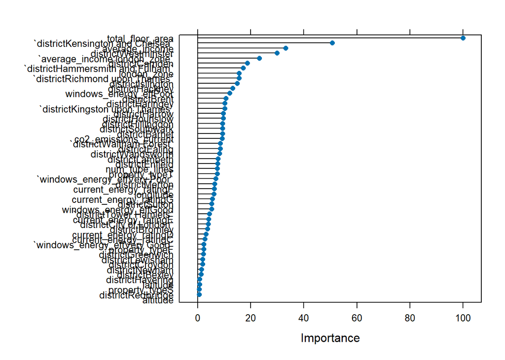

```r
# Calculate the variable importance for the trained linear regression model
importance <- varImp(model1_lm_interaction, scale = TRUE)  # Use 'varImp' function to calculate the importance of each predictor variable, scaling the importance values to make them comparable

# Plot the variable importance results
plot(importance)
```

```r
# Generate predictions using the trained model on the test dataset
predictions_interaction <- predict(model1_lm_interaction, test_data)  # Use the 'predict' function to make predictions on the 'test_data' using the trained model

# Calculate performance metrics (RMSE and R-squared) for the model on the test dataset
lr_results_interaction <- data.frame(  # Create a data frame to store model performance results
    RMSE = RMSE(predictions_interaction, test_data$price),  # Calculate the Root Mean Squared Error (RMSE) between the predicted and actual prices
    Rsquare = R2(predictions_interaction, test_data$price)  # Calculate the R-squared value, a measure of how well the model explains the variance in the actual prices
)

# Display the model performance results for the test dataset
lr_results_interaction  # Output the results (RMSE and R-squared) for the test dataset
```

```
##       RMSE   Rsquare
## 1 278930.2 0.6945014
```

```r
# Predict prices for out-of-sample (OOS) data using the trained model
predictions_oos_interaction <- predict(model1_lm_interaction, london_house_prices_2019_out_of_sample)  # Make predictions on the out-of-sample data

# Calculate performance metrics (RMSE and R-squared) for the model on the out-of-sample dataset
lr_results_oos_interaction <- data.frame(  # Create a data frame to store the performance metrics
    RMSE = RMSE(predictions_oos_interaction, london_house_prices_2019_out_of_sample$asking_price),  # Calculate RMSE for out-of-sample predictions
    Rsquare = R2(predictions_oos_interaction, london_house_prices_2019_out_of_sample$asking_price)  # Calculate R-squared for out-of-sample predictions
)

# Display the model performance results for the out-of-sample dataset
lr_results_oos_interaction  # Output the results (RMSE and R-squared) for the out-of-sample dataset
```

```
##       RMSE   Rsquare
## 1 420973.9 0.6208913
```

# 5 Fit a tree model

Next I fit a tree model using the same subset of features. Again you can (and should) add more variables and tune the parameter of your tree to find a better fit.

Compare the performance of the linear regression model with the tree model; which one performs better? Why do you think that is the case?

### 5.0.1 Without Interaction Variables

```r
# # Train a decision tree model (using rpart method) without interaction terms
# model2_tree <- train(  # Use the 'train' function from caret to train the model
#   formula_without_interaction_var,  # Use the formula without interaction terms for the model
#
#   train_data,  # Use the 'train_data' dataset for training the model
#
#   method = "rpart",  # Specify that the model type is a decision tree (rpart stands for recursive partitioning)
#
#   trControl = control,  # Use the predefined 'control' settings for cross-validation (5-fold cross-validation)
#
#   tuneLength = 8  # Perform hyperparameter tuning, testing 8 different values for the tree complexity parameter
# )
#
# # View the performance results of the decision tree model
# model2_tree$results  # Display the model performance metrics (e.g., RMSE, accuracy) from the cross-validation results
#
# # Visualize the final decision tree
# rpart.plot(model2_tree$finalModel)  # Use the 'rpart.plot' function to visualize the structure of the final decision tree
#
# # Calculate and visualize the variable importance for the decision tree model
# importance <- varImp(model2_tree, scale = TRUE)  # Calculate the importance of each predictor variable in the decision tree model, scaling the values for comparability
#
# plot(importance)  # Plot the variable importance, showing the relative importance of each predictor variable in predicting the target variable
```

```r
# # Train a decision tree model (using rpart method) without interaction terms
# model2_tree <- train(  # Use the 'train' function from caret to train the model
#   formula_without_interaction_var,  # Use the formula without interaction terms for the model
#
#   train_data,  # Use the 'train_data' dataset for training the model
#
#   method = "rpart",  # Specify that the model type is a decision tree (rpart stands for recursive partitioning)
#
#   trControl = control,  # Use the predefined 'control' settings for cross-validation (5-fold cross-validation)
#
#   tuneLength = 10  # Perform hyperparameter tuning, testing 10 different values for the tree complexity parameter
# )
#
# # View the performance results of the decision tree model
# model2_tree$results  # Display the model performance metrics (e.g., RMSE, accuracy) from the cross-validation results
#
# # Visualize the final decision tree
# rpart.plot(model2_tree$finalModel)  # Use the 'rpart.plot' function to visualize the structure of the final decision tree
#
# # Calculate and visualize the variable importance for the decision tree model
# importance <- varImp(model2_tree, scale = TRUE)  # Calculate the importance of each predictor variable in the decision tree model, scaling the values for comparability
#
# plot(importance)  # Plot the variable importance, showing the relative importance of each predictor variable in predicting the target variable
```

```r
# # Train a decision tree model (using rpart method) without interaction terms
# model2_tree <- train(  # Use the 'train' function from caret to train the model
#   formula_without_interaction_var,  # Use the formula without interaction terms for the model
#
#   train_data,  # Use the 'train_data' dataset for training the model
#
#   method = "rpart",  # Specify that the model type is a decision tree (rpart stands for recursive partitioning)
#
#   trControl = control,  # Use the predefined 'control' settings for cross-validation (5-fold cross-validation)
#
#   tuneLength = 15  # Perform hyperparameter tuning, testing 15 different values for the tree complexity parameter
# )
#
# # View the performance results of the decision tree model
# model2_tree$results  # Display the model performance metrics (e.g., RMSE, accuracy) from the cross-validation results
#
# # Visualize the final decision tree
# rpart.plot(model2_tree$finalModel)  # Use the 'rpart.plot' function to visualize the structure of the final decision tree
#
# # Calculate and visualize the variable importance for the decision tree model
# importance <- varImp(model2_tree, scale = TRUE)  # Calculate the importance of each predictor variable in the decision tree model, scaling the values for comparability
#
# plot(importance)  # Plot the variable importance, showing the relative importance of each predictor variable in predicting the target variable
```

```r
# # Train a decision tree model (using rpart method) without interaction terms
# model2_tree <- train(  # Use the 'train' function from caret to train the model
#   formula_without_interaction_var,  # Use the formula without interaction terms for the model
#
#   train_data,  # Use the 'train_data' dataset for training the model
#
#   method = "rpart",  # Specify that the model type is a decision tree (rpart stands for recursive partitioning)
#
#   trControl = control,  # Use the predefined 'control' settings for cross-validation (5-fold cross-validation)
#
#   tuneLength = 12  # Perform hyperparameter tuning, testing 12 different values for the tree complexity parameter
# )
#
# # View the performance results of the decision tree model
# model2_tree$results  # Display the model performance metrics (e.g., RMSE, accuracy) from the cross-validation results
#
# # Visualize the final decision tree
# rpart.plot(model2_tree$finalModel)  # Use the 'rpart.plot' function to visualize the structure of the final decision tree
#
# # Calculate and visualize the variable importance for the decision tree model
# importance <- varImp(model2_tree, scale = TRUE)  # Calculate the importance of each predictor variable in the decision tree model, scaling the values for comparability
#
# plot(importance)  # Plot the variable importance, showing the relative importance of each predictor variable in predicting the target variable
```

```r
# predictions_tree <- predict(model2_tree,test_data)
#
# lr_results_tree<-data.frame(  RMSE = RMSE(predictions_tree, test_data$price),
#                             Rsquare = R2(predictions_tree, test_data$price))
#
#
# lr_results_tree
```

### 5.0.2 With Interaction Variables

```r
# # Train a decision tree model (using rpart method) without interaction terms
model2_tree_interaction <- train(  # Use the 'train' function from caret to train the model
  formula_interaction_var,  # Use the formula without interaction terms for the model

  train_data,  # Use the 'train_data' dataset for training the model

  method = "rpart",  # Specify that the model type is a decision tree (rpart stands for recursive partitioning)

  trControl = control,  # Use the predefined 'control' settings for cross-validation (5-fold cross-validation)

  tuneLength = 12  # Perform hyperparameter tuning, testing 12 different values for the tree complexity parameter
)
# View the performance results of the decision tree model
model2_tree_interaction$results  # Display the model performance metrics (e.g., RMSE, accuracy) from the cross-validation results
```

```
##             cp     RMSE  Rsquared      MAE   RMSESD  RsquaredSD     MAESD
## 1  0.007833701 289566.8 0.6980094 161661.1 13712.50 0.026090940  5306.245
## 2  0.009013303 291856.2 0.6910687 164431.6 13236.06 0.030259211  3490.424
## 3  0.011162656 298117.6 0.6765905 168647.5 11451.41 0.042771942  5269.590
## 4  0.013565035 301765.0 0.6683556 171967.6 11276.47 0.049392849  7231.575
## 5  0.013571951 301765.0 0.6683556 171967.6 11276.47 0.049392849  7231.575
## 6  0.024588859 322249.5 0.6216293 180779.3 14022.40 0.051351345  3439.106
## 7  0.025599722 322249.5 0.6216293 180779.3 14022.40 0.051351345  3439.106
## 8  0.037466924 343776.6 0.5717925 190713.5 27874.43 0.048952434  7140.106
## 9  0.042348408 353888.6 0.5461222 194099.8 33079.76 0.039171089  8265.032
## 10 0.075273739 377506.3 0.4829492 213268.3 35492.73 0.034141615 14072.656
## 11 0.161285504 418283.9 0.3601466 231223.0 44913.95 0.087860300  7750.679
## 12 0.310961294 471073.5 0.2874245 253969.6 26503.46 0.006861207 26099.117
```

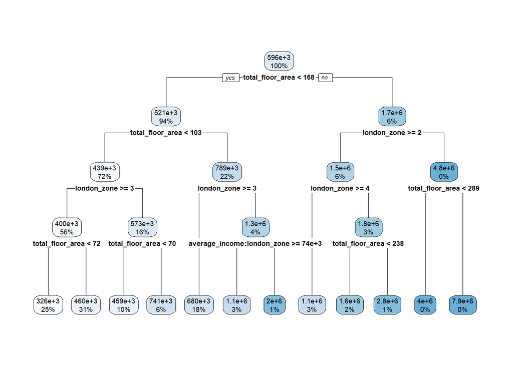

```r
# Visualize the final decision tree
rpart.plot(model2_tree_interaction$finalModel)  # Use the 'rpart.plot' function to visualize the structure of the final decision tree
```

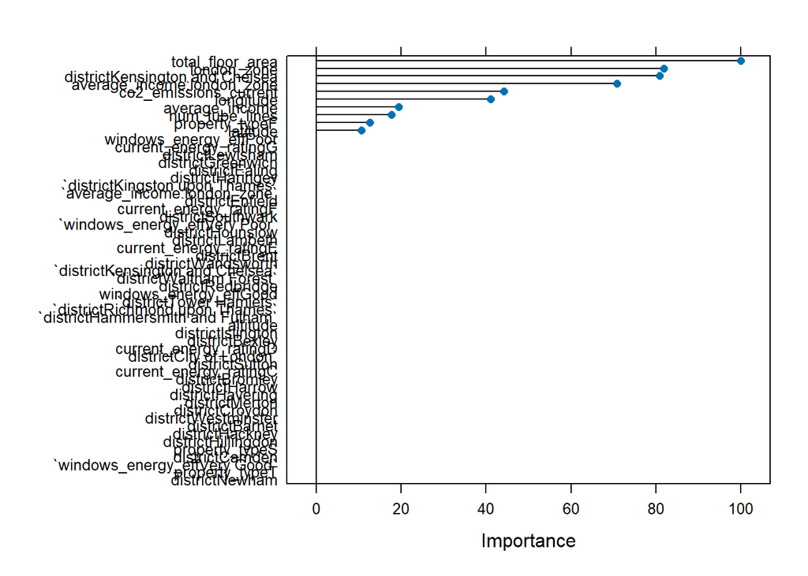

```r
# Calculate and visualize the variable importance for the decision tree model
importance <- varImp(model2_tree_interaction, scale = TRUE)  # Calculate the importance of each predictor variable in the decision tree model, scaling the values for comparability

plot(importance)  # Plot the variable importance, showing the relative importance of each predictor variable in predicting the target variable
```

```r
# Generate predictions using the trained decision tree model with interaction terms on the test dataset
predictions_tree_interaction <- predict(model2_tree_interaction, test_data)  # Use the 'predict' function to make predictions on the 'test_data' using the trained model with interaction terms

# Calculate performance metrics (RMSE and R-squared) for the model on the test dataset
lr_results_tree_interaction <- data.frame(  # Create a data frame to store model performance results
    RMSE = RMSE(predictions_tree_interaction, test_data$price),  # Calculate the Root Mean Squared Error (RMSE) between the predicted and actual prices
    Rsquare = R2(predictions_tree_interaction, test_data$price)  # Calculate the R-squared value, which shows how well the model explains the variance in the actual prices
)

# Display the model performance results for the test dataset
lr_results_tree_interaction  # Output the results (RMSE and R-squared) for the test dataset
```

```
##       RMSE   Rsquare
## 1 288375.2 0.6761819
```

```r
# Predict prices for out-of-sample (OOS) data using the trained model with interaction terms
predictions_oos_tree_interaction <- predict(model2_tree_interaction, london_house_prices_2019_out_of_sample)  # Use the trained model to make predictions on the out-of-sample data
```

# 6 Other algorithms

Use at least two other algorithms to predict prices. Don’t forget to tune the parameters of these algorithms. And then compare the performances of your algorithms to linear regression and trees.

## 6.1 Lasso Regression

```r
# Define a list of predictor variables for the Lasso regression model
predictor_list <- c("property_type",  # Include property type as a predictor
                    "current_energy_rating",  # Include current energy rating as a predictor
                    "total_floor_area",  # Include total floor area as a predictor
                    "average_income",  # Include average income as a predictor
                    "london_zone",  # Include London zone as a predictor
                    "num_tube_lines",  # Include the number of tube lines nearby as a predictor
                    "windows_energy_eff",  # Include windows energy efficiency as a predictor
                    "district")  # Include district as a predictor

# Extract the predictor variables from the training data
train_predictors <- train_data[, predictor_list]  # Select the columns specified in the predictor_list

# Extract the response variable (price) from the training data
train_response <- train_data$price  # Select the 'price' column as the response variable

# Convert the predictors to a numeric matrix, removing the intercept term (the first column generated by model.matrix)
train_predictors_matrix <- model.matrix(~., data = train_predictors)[, -1]  # This creates a design matrix without the intercept

# Train a Lasso regression model with 10-fold cross-validation
lasso_model <- cv.glmnet(train_predictors_matrix, train_response, alpha = 1, nfolds = 10)  # alpha = 1 for Lasso (L1 regularization), nfolds = 10 for 10-fold cross-validation

# Display the best lambda value (the penalty parameter that minimizes the cross-validation error)
best_lambda <- lasso_model$lambda.min  # Extract the lambda value that results in the lowest cross-validation error
cat("Optimal Lambda (Penalty):", best_lambda, "\n")  # Print the optimal lambda value
```

```
## Optimal Lambda (Penalty): 160.1741
```

```r
# Extract the coefficients corresponding to the best lambda
lasso_coefficients <- coef(lasso_model, s = "lambda.min")  # Get the coefficients for the model at the optimal lambda
print(lasso_coefficients)  # Display the coefficients of the Lasso model
```

```
## 49 x 1 sparse Matrix of class "dgCMatrix"
##                                           s1
## (Intercept)                    -2.945814e+05
## property_typeF                  2.330108e+04
## property_typeS                  8.018792e+03
## property_typeT                  5.735001e+04
## current_energy_ratingC         -1.806988e+04
## current_energy_ratingD         -6.002436e+03
## current_energy_ratingE          3.827484e+03
## current_energy_ratingF         -1.072995e+04
## current_energy_ratingG         -4.107738e+04
## total_floor_area                7.429851e+03
## average_income                  6.176636e+00
## london_zone                    -6.001824e+04
## num_tube_lines                  1.729734e+04
## windows_energy_effGood          1.877741e+04
## windows_energy_effPoor          7.626524e+04
## windows_energy_effVery Good     1.876078e+05
## windows_energy_effVery Poor     4.192507e+04
## districtBarnet                  2.186365e+04
## districtBexley                 -1.760621e+04
## districtBrent                   4.679571e+04
## districtBromley                -2.849387e+04
## districtCamden                  2.171083e+05
## districtCity of London          2.552770e+05
## districtCroydon                -9.612156e+04
## districtEaling                  1.313352e+04
## districtEnfield                 1.338411e+04
## districtGreenwich              -5.354048e+04
## districtHackney                 6.978161e+04
## districtHammersmith and Fulham  2.282073e+05
## districtHaringey                3.567802e+04
## districtHarrow                  1.898415e+04
## districtHavering                2.959715e+04
## districtHillingdon              4.832104e+04
## districtHounslow                6.669807e+04
## districtIslington               1.363872e+05
## districtKensington and Chelsea  9.860727e+05
## districtKingston upon Thames    5.364789e+04
## districtLambeth                 9.277749e+03
## districtLewisham               -8.946389e+04
## districtMerton                 -1.113640e+04
## districtNewham                 -9.916470e+04
## districtRedbridge              -8.529854e+04
## districtRichmond upon Thames    1.603459e+05
## districtSouthwark               2.442876e+04
## districtSutton                 -2.689202e+04
## districtTower Hamlets          -3.296664e+04
## districtWaltham Forest          7.328998e+03
## districtWandsworth              3.593536e+04
## districtWestminster             5.044207e+05
```

```r
# Extract the predictor variables from the test data, using the same list as for the training data
test_predictors <- test_data[, predictor_list]  # Select the columns specified in the 'predictor_list' from the test dataset

# Convert the test predictors to a numeric matrix, removing the intercept term (same as in training data preprocessing)
test_predictors_matrix <- model.matrix(~., data = test_predictors)[, -1]  # This creates a design matrix without the intercept

# Predict using the trained Lasso model (the model trained earlier)
predictions_lasso <- predict(lasso_model, newx = test_predictors_matrix, s = "lambda.min")  # Use the 'predict' function to generate predictions on the test set, using the optimal lambda

# Calculate performance metrics (RMSE and R-squared) for the model's predictions on the test dataset
lr_results_lasso <- data.frame(  # Create a data frame to store the performance metrics
    RMSE = RMSE(predictions_lasso, test_data$price),  # Calculate the Root Mean Squared Error (RMSE) between the predicted and actual prices
    Rsquare = R2(predictions_lasso, test_data$price)  # Calculate the R-squared value for the model's performance on the test data
)

# Display the model performance results for the test dataset
lr_results_lasso  # Output the results (RMSE and R-squared) for the test dataset
```

```
##       RMSE lambda.min
## 1 282581.8  0.6862965
```

## 6.2 Random Forest

### 6.2.1 Without Interaction Variables

```r
# # Define a grid of hyperparameters for tuning the Random Forest model
# gridRF <- data.frame(  # Create a data frame to specify the grid of hyperparameters for tuning
#   .mtry = c(2:5),  # Number of variables to try at each split (mtry), ranging from 2 to 5
#   .splitrule = "variance",  # Specify the splitting rule used by the model (here, using variance as the criterion)
#   .min.node.size = 5  # Minimum number of data points in a terminal node (leaf node) of the tree
# )
#
# # Fit a Random Forest model using the 'ranger' method from the caret package
# rf_model <- train(  # Use the 'train' function from the caret package to train the model
#   formula_without_interaction_var,  # The formula for the model, without interaction terms
#   data = train_data,  # The training data used to fit the model
#   method = "ranger",  # Specify the 'ranger' method for Random Forest, an efficient implementation
#   metric = "RMSE",  # Specify that the performance metric to optimize is RMSE (Root Mean Squared Error)
#   trControl = control,  # Use the predefined cross-validation settings (control)
#   tuneGrid = gridRF,  # Use the hyperparameter grid defined earlier to tune the model
#   importance = 'permutation'  # Specify that variable importance should be calculated using permutation importance
# )
```

```r
# # Generate predictions on the test dataset using the trained Random Forest model
# predictions_rf <- predict(rf_model, newdata = test_data)  # Use the 'predict' function to make predictions on the 'test_data' using the trained Random Forest model
#
# # Calculate performance metrics (RMSE and R-squared) for the Random Forest model's predictions on the test dataset
# lr_results_rf <- data.frame(  # Create a data frame to store the performance results
#     RMSE = RMSE(predictions_rf, test_data$price),  # Calculate the Root Mean Squared Error (RMSE) between the predicted and actual prices
#     Rsquare = R2(predictions_rf, test_data$price)  # Calculate the R-squared value, which measures how well the model explains the variance in the actual prices
# )
#
# # Display the model performance results for the test dataset
# lr_results_rf  # Output the results (RMSE and R-squared) for the Random Forest model on the test dataset
#
# # Predict house prices for out-of-sample data (not part of the test set) using the trained Random Forest model
# predictions_rf_oos <- predict(rf_model, london_house_prices_2019_out_of_sample)  # Use the trained Random Forest model to make predictions on the out-of-sample data
```

### 6.2.2 With Interaction Variables

```r
# Define a grid of hyperparameters for tuning the Random Forest model
gridRF <- data.frame(  # Create a data frame to specify the grid of hyperparameters for tuning
  .mtry = c(2:5),  # Number of variables to consider at each split (mtry), ranging from 2 to 5
  .splitrule = "variance",  # Splitting rule for decision trees, using variance as the criterion to minimize
  .min.node.size = 5  # Minimum number of data points allowed in a terminal (leaf) node of the tree
)

# Fit a Random Forest model using the 'ranger' method from the caret package, incorporating interaction terms
rf_model_interaction <- train(  # Use the 'train' function from the caret package to train the model
  formula_interaction_var,  # The formula for the model, which includes interaction terms between predictors
  data = train_data,  # The training dataset used to train the model
  method = "ranger",  # Specify the 'ranger' method, which is a fast implementation of Random Forest (highly efficient)
  metric = "RMSE",  # The performance metric to optimize is RMSE (Root Mean Squared Error)
  trControl = control,  # Cross-validation control settings (previously defined in your code), defines how resampling is handled (e.g., 5-fold cross-validation)
  tuneGrid = gridRF,  # The hyperparameter grid defined earlier to tune the Random Forest model based on values for mtry, splitrule, and min.node.size
  importance = 'permutation'  # Specify that variable importance should be calculated using the permutation method (measuring how much the model performance drops when a feature is randomly shuffled)
)
# Generate predictions on the test dataset using the trained Random Forest model with interaction terms
predictions_rf_interaction <- predict(rf_model_interaction, newdata = test_data)  # Use the trained Random Forest model with interaction terms to predict house prices on the test data

# Calculate performance metrics (RMSE and R-squared) for the Random Forest model's predictions on the test dataset
lr_results_rf <- data.frame(  # Create a data frame to store the evaluation results
    RMSE = RMSE(predictions_rf_interaction, test_data$price),  # Calculate the Root Mean Squared Error (RMSE) between the predicted and actual prices
    Rsquare = R2(predictions_rf_interaction, test_data$price)  # Calculate R-squared, which measures the proportion of variance in the data explained by the model
)

# Display the model performance results for the test dataset
lr_results_rf  # Output the performance results (RMSE and R-squared) for the Random Forest model on the test data
```

```
##     RMSE   Rsquare
## 1 223858 0.8226826
```

```r
# Predict house prices for out-of-sample data (not part of the test set) using the trained Random Forest model
predictions_rf_oos <- predict(rf_model_interaction, london_house_prices_2019_out_of_sample)  # Use the trained Random Forest model with interaction terms to predict house prices on the out-of-sample data
```

## 6.3 GBM

### 6.3.1 Without Interaction

```r
# grid<-expand.grid(
#   interaction.depth = c(3, 5, 7),  # Test different values for interaction depth
#   n.trees = c(100, 200, 300),      # Test different values for the number of trees
#   shrinkage = c(0.01, 0.03, 0.1),  # Test different shrinkage values
#   n.minobsinnode = c(5, 10, 20)
# )
#
# gbm_model <-  train(
#                formula_without_interaction_var,
#                data=train_data,
#                method = "gbm",
#                trControl = control,
#                metric="RMSE",
#                preProcess = c("center", "scale"),
#                tuneGrid=grid,
#                verbose=FALSE
# )
```

```r
# # Define a grid of hyperparameters to tune the Gradient Boosting Machine (GBM) model
# grid <- expand.grid(  # Use expand.grid to create a grid of hyperparameters to be tested
#   interaction.depth = 5,  # The maximum depth of each tree. Here, it is set to 5 to test models with trees of depth 5.
#   n.trees = 200,  # The number of trees in the ensemble. A higher number of trees can improve performance but also increases computational cost. Here, it's set to 200.
#   shrinkage = 0.1,  # The learning rate, also known as shrinkage. A smaller value (like 0.1) indicates slower learning but can lead to better generalization.
#   n.minobsinnode = 5  # The minimum number of observations allowed in a terminal node of the tree. Here, it's set to 5, balancing model complexity and data efficiency.
# )
#
# # Fit a Gradient Boosting Machine (GBM) model using the caret package's train function
# gbm_model <- train(  # The 'train' function trains the model based on the defined formula and settings
#   formula_without_interaction_var,  # The model formula, which includes predictors without interaction terms
#   data = train_data,  # The training dataset used to fit the model
#   method = "gbm",  # Specifies the GBM algorithm, which fits an ensemble of decision trees using boosting
#   trControl = control,  # Resampling control settings (cross-validation), defined earlier
#   metric = "RMSE",  # Root Mean Squared Error (RMSE) will be the optimization criterion for training
#   preProcess = c("center", "scale"),  # Data preprocessing steps to center and scale the predictors before training the model
#   tuneGrid = grid,  # The grid of hyperparameters to be tested, as defined earlier
#   verbose = FALSE  # Suppress the verbose output during training to keep the console clean
# )
```

```r
# Generate predictions on the test dataset using the trained GBM model
# predictions_gbm <- predict(gbm_model, newdata = test_data)  # Use the trained GBM model to predict house prices for the test data
#
# # Calculate performance metrics (RMSE and R-squared) for the GBM model's predictions on the test dataset
# lr_results_gbm <- data.frame(  # Create a data frame to store the evaluation results
#     RMSE = RMSE(predictions_gbm, test_data$price),  # Calculate the Root Mean Squared Error (RMSE) between the predicted and actual prices
#     Rsquare = R2(predictions_gbm, test_data$price)  # Calculate R-squared, which indicates the proportion of variance explained by the model
# )
#
# # Display the model performance results for the test dataset
# lr_results_gbm  # Output the RMSE and R-squared results for the GBM model on the test data
#
# # Predict house prices for out-of-sample data (not part of the test set) using the trained GBM model
# predictions_gbm_oos <- predict(gbm_model, london_house_prices_2019_out_of_sample)  # Predict house prices on the out-of-sample data
```

### 6.3.2 With Interaction

```r
# Define a grid of hyperparameters to tune the Gradient Boosting Machine (GBM) model with interaction terms
grid <- expand.grid(  # Use expand.grid to create a grid of hyperparameters to be tested
  interaction.depth = 5,  # Maximum depth of the trees. A depth of 5 means each tree can have up to 5 levels of splits. This controls the complexity of each tree.
  n.trees = 200,  # Number of trees in the ensemble. Here, it's set to 200, which is a typical value for boosting models.
  shrinkage = 0.1,  # Learning rate (shrinkage). A smaller value of 0.1 slows down learning and can help improve generalization.
  n.minobsinnode = 5  # Minimum number of observations in a terminal (leaf) node. This prevents overfitting by ensuring that each terminal node has at least 5 data points.
)

# Fit a Gradient Boosting Machine (GBM) model with interaction terms using the caret package's train function
gbm_model_interaction <- train(  # Train the GBM model with the specified parameters and formula
  formula_interaction_var,  # The model formula that includes interaction terms between predictors
  data = train_data,  # The training dataset used to fit the model
  method = "gbm",  # Specifies the Gradient Boosting Machine (GBM) algorithm to use
  trControl = control,  # Resampling control settings (cross-validation), previously defined in the code
  metric = "RMSE",  # The model will optimize based on RMSE (Root Mean Squared Error)
  preProcess = c("center", "scale"),  # Data preprocessing steps: centering (subtracting the mean) and scaling (dividing by the standard deviation)
  tuneGrid = grid,  # The grid of hyperparameters (defined above) to test during model training
  verbose = FALSE  # Suppresses detailed output during the training process to keep the console clean
)
# Predict house prices on the test data using the trained GBM model with interaction terms
predictions_gbm_interaction <- predict(gbm_model_interaction, newdata = test_data)
# The `predict` function uses the trained model (gbm_model_interaction) to make predictions on the test data.
# `newdata = test_data` specifies that predictions should be made on the test dataset.

# Calculate the model's performance on the test data
lr_results_gbm_interaction <- data.frame(
  RMSE = RMSE(predictions_gbm_interaction, test_data$price),  # Compute the Root Mean Squared Error (RMSE) between the predicted and actual prices
  Rsquare = R2(predictions_gbm_interaction, test_data$price)  # Compute R-squared value to assess how well the model explains the variation in the price
)

# Display the performance results for the test data
lr_results_gbm_interaction
```

```
##       RMSE   Rsquare
## 1 202983.2 0.8391883
```

```r
# Predict house prices for out-of-sample data using the trained GBM model with interaction terms
predictions_gbm_oos_interaction <- predict(gbm_model_interaction, london_house_prices_2019_out_of_sample)
```

# 7 Stacking

Use stacking to ensemble your algorithms.

### 7.0.1 Without Interaction Variables

```r
# To implement stacking, first train all the models that you will use in the ensemble
# model_list <- caretList(
#     formula_without_interaction_var,  # Formula to define the relationship between the predictors and the target variable
#     data = train_data,  # The training dataset to be used for model training
#
#     trControl = control,  # Control options that define the resampling method, number of folds, etc. (previously defined control object)
#
#     metric = "RMSE",  # Metric to evaluate model fit, in this case, RMSE (Root Mean Squared Error)
#
#     methodList = c("lm"),  # List of methods to train models; "lm" indicates linear regression
#
#     tuneList = list(  # A list of custom models with tuning parameters for the stacking procedure
#
#       ranger = caretModelSpec(  # Random forest model (method "ranger") with specific tuning parameters
#
#         method = "ranger",  # Random forest algorithm
#
#         tuneGrid = data.frame(mtry = 5, splitrule = "variance", min.node.size = 5),  # Hyperparameters for tuning the Random Forest model
#
#         importance = 'permutation'  # Use permutation method for calculating feature importance
#       ),
#       rpart = caretModelSpec(  # Decision tree model (method "rpart") with specified tuning parameters
#
#         method = "rpart",  # Classification and regression trees (CART) algorithm
#
#         tuneGrid = data.frame(cp = 0.0011),  # Complexity parameter for pruning (controls tree size)
#
#         minbucket = 2,  # Minimum number of observations required in a terminal node
#         tuneLength = 12  # Number of parameter combinations to be tested for tuning
#       ),
#       gbm = caretModelSpec(  # Gradient boosting model (method "gbm") with specific tuning parameters
#         method = "gbm",  # Gradient Boosting Machine algorithm
#
#         tuneGrid = data.frame(  # Hyperparameters for the GBM model
#
#           interaction.depth = 5,  # Maximum depth of the trees (controls complexity)
#           n.trees = 200,  # Number of trees in the model
#           shrinkage = 0.1,  # Learning rate (shrinkage)
#           n.minobsinnode = 5  # Minimum number of observations in a terminal node
#         ),
#         verbose = FALSE,  # Disable verbose output during training
#
#         preProcess = c("center", "scale")  # Preprocess the data by centering and scaling
#       )
#     )
# )
```

```r
# resamples <- resamples(model_list)
#
# summary(resamples)
```

```r
# lm_ensemble <- caretStack(
#     model_list, #Models we trained above in caretList
#     method="lm", #Use linear regression to combine
#     metric="RMSE", #Use RMSE to as measure of fit quality
#     trControl=control
#   )
#
# summary(lm_ensemble)
```

```r
# Use the trained ensemble model (lm_ensemble) to make predictions on the test data
# predictions_ensemble <- predict(lm_ensemble, test_data)
#
# # Calculate the RMSE (Root Mean Squared Error) and R-squared for the ensemble model's predictions
# lr_results_ensemble <- data.frame(
#   RMSE = RMSE(predictions_ensemble$pred, test_data$price),  # RMSE measures the average error between predicted and actual prices
#
#   Rsquare = R2(predictions_ensemble$pred, test_data$price)  # R-squared measures the proportion of variance explained by the model
# )
#
# # Display the performance metrics (RMSE and R-squared) of the ensemble model on the test data
# lr_results_ensemble
#
# # Use the trained ensemble model (lm_ensemble) to make predictions on out-of-sample data
# # These predictions can be used for forecasting or evaluating model generalization
# predictions_oos_ensemble <- predict(lm_ensemble, london_house_prices_2019_out_of_sample)
```